# GreatShoools Ratings - Preliminary Results

Magdalena Bennett

August 3rd, 2022

# Setup

## General Framework

GreatSchools uses ratings to categorize schools depending on how they perform according to different characteristics: from test scores to equity to student progress. The summary rating for school $i$ $R_i$ is built as following:

$$R_i = \lfloor r_i \rceil$$
where $r_i$ represents the continuous rating for school $i$, which is a weighted average of the schools subratings. Suppose school $i$ has $P$ subratings, then $r_i$ is constructed as following:

$$r_i = \sum_{p=1}^P \omega_{ip}\cdot s_{ip}$$
where $s_{ip} \in \{1, 2, ...,10\}$ is the subrating $p$ (e.g. test scores, student progress) for school $i$, $\omega_{ip}$ is the weight assigned for subrating $p$, and $\sum_{p=1}^P \omega_{ip} = 1$.

The objective of the following analysis is to leverage the discrete nature of the ratings $R_i$ to study the effect of ratings on schools’ demographic characteristics. For example, do higher rated schools concentrate a lower proportion of minority students compared to schools with similar $r_i$ but that are categorized differently?

By using a regression discontinuity design, we will exploit the different discontinuities in the ratings assignments to answer the previous question.

## Continuity issues

One problem, however, is that depending on the number of subratings used to built $R_i$ for each school, the running variable $r_i$ might not be as smooth as we would like. For that reason, we will build a smoother version of $r_i$, which we will call $r^*_i$, using the continuous version of one of the subratings instead of the discrete version:

$$r^*_{i} = \omega_{iT}\cdot (s^*_{iT}\cdot 10 + 0.5) + \sum_{p=2}^P\omega_{ip} \cdot s_{ip}$$
where $s^*_{iT}$ represents the *continuous* version of the test score subrating ($s^* \in [0, 1]$).

Using $r^*_i$ instead of $r_i$ has the advantage that even under a small $P$, the running variable is much smoother.

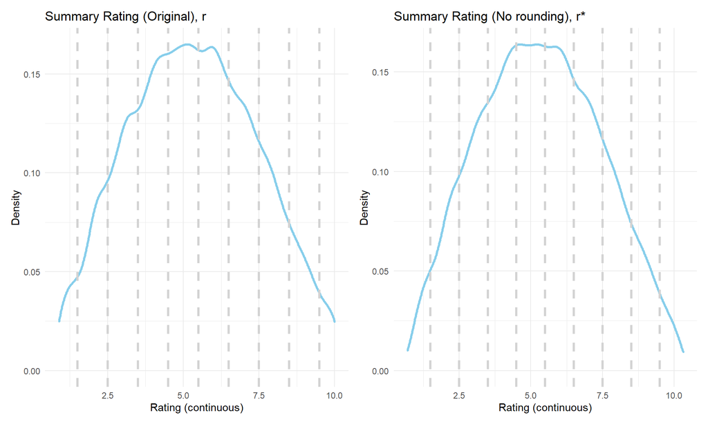

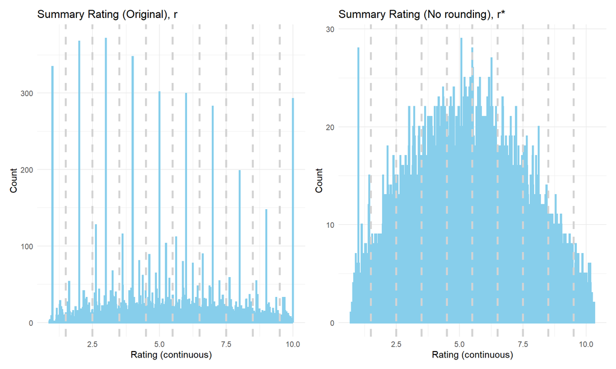

One drawback of using $r^*$ instead of $r$ is that depending on $\omega_{iT}$, we no longer have perfect compliance of ratings at the threshold. This means that in order to obtain the LATE at the threshold, we will need to use a fuzzy RD approach instead of a sharp RD.

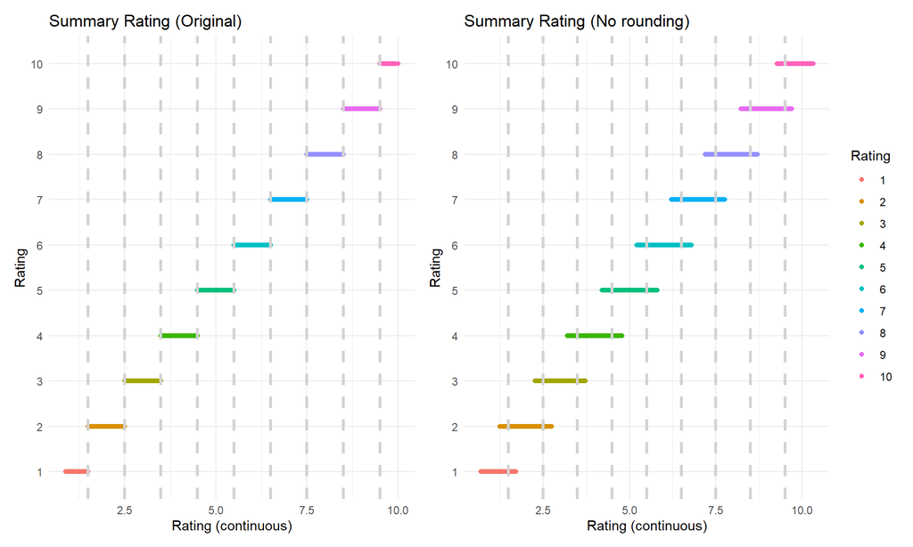

# Main Results

In this section, we will show the results for 2019 demographic characteristics of schools using the oldest ratings data we have available with a running variable, which is end of 2017. We will focus only on non-virtual elementary schools, and those that have at least 3 subratings to built the summary rating.

In terms of covariates, we will use both census data (at the tract level) as well as CCD data for different years to adjust for baseline differences between schools.

## Data description

School Chacteristics by Rating

|  | 1 | 2 | 3 | 4 | 5 | 6 | 7 | 8 | 9 | 10 |
| --- | --- | --- | --- | --- | --- | --- | --- | --- | --- | --- |
| Census Population 2010 (Tract) | 3314.35 | 3737.63 | 3996.97 | 4198.59 | 4359.20 | 4449.63 | 4524.08 | 4581.11 | 4751.05 | 4717.26 |
| % Black Population 2010 (Tract) | 0.47 | 0.35 | 0.25 | 0.18 | 0.14 | 0.11 | 0.09 | 0.07 | 0.06 | 0.12 |
| % Poverty 2010 (Tract) | 0.27 | 0.23 | 0.19 | 0.16 | 0.14 | 0.12 | 0.11 | 0.09 | 0.09 | 0.12 |
| Total Students 2013 (School) | 490.01 | 517.25 | 528.34 | 528.64 | 527.63 | 530.02 | 546.61 | 561.37 | 576.15 | 643.48 |
| % Black 2013 (School) | 61.97 | 45.00 | 32.01 | 21.33 | 15.83 | 12.61 | 9.32 | 7.75 | 5.83 | 10.96 |
| % Hispanic 2013 (School) | 19.93 | 26.13 | 28.95 | 26.89 | 22.73 | 20.52 | 18.27 | 16.25 | 16.09 | 27.92 |
| Total Students 2017 (School) | 452.50 | 492.38 | 510.24 | 512.82 | 517.05 | 529.35 | 546.90 | 568.83 | 589.42 | 721.80 |
| % Black 2017 (School) | 61.19 | 45.44 | 32.68 | 21.79 | 16.42 | 13.08 | 9.78 | 7.98 | 6.06 | 10.49 |
| % Hispanic 2017 (School) | 21.97 | 28.34 | 30.85 | 28.82 | 24.42 | 21.97 | 19.69 | 17.35 | 17.31 | 30.09 |
| Num. subratings | 3.13 | 3.15 | 3.11 | 3.09 | 3.07 | 3.04 | 3.03 | 3.01 | 3.00 | 3.00 |
| Subrating Test Scores | 0.06 | 0.14 | 0.24 | 0.36 | 0.48 | 0.61 | 0.72 | 0.82 | 0.89 | 0.95 |
| Compliance | 1.00 | 0.98 | 0.96 | 0.96 | 0.94 | 0.95 | 0.93 | 0.93 | 0.93 | 0.96 |
| N | 1443.00 | 3581.00 | 5530.00 | 6719.00 | 7026.00 | 6976.00 | 5622.00 | 4034.00 | 2296.00 | 1125.00 |

Compliance refers to whether a school is categorized as their observed ranking when rounding r*

## Original Running Variable

In this section, we will show some results for the traditional RD approach, using the original running variable $r$. We show results for the RD with and without covariates. In terms of covariates, we use the number of black students in each school in 2013, as well as the total number of students in the school (enrollment) in 2013.

Note: The specification assumes that $r>h$ (running variable above the threshold) is the “treatment”, and $r<h$ is the control. Then, a negative coefficient indicates that the lower rating has a higher level of the outcome compared to the higher rating.

RD results for number of Black students in 2019 (running variable r)

|  | N Black students 2019 (No Covs) | N Black students 2019 (Covs) |
| --- | --- | --- |
| 1-2 | 25.445 | -12.508 |
|  | (20.326) | (10.318) |
|  | [367;345] | [282;252] |
| 2-3 | 20.184 | -3.162 |
|  | (12.522) | (4.885) |
|  | [1056;1035] | [796;791] |
| 3-4 | 0.418 | 3.459 |
|  | (8.912) | (4.454) |
|  | [1740;1839] | [1061;1115] |
| 4-5 | -22.341** | -3.004 |
|  | (10.868) | (2.423) |
|  | [1058;951] | [2570;2321] |
| 5-6 | 0.996 | 0.934 |
|  | (8.809) | (2.869) |
|  | [1166;1076] | [1406;1335] |
| 6-7 | -37.169*** | 8.978*** |
|  | (7.824) | (2.171) |
|  | [1025;980] | [1311;1218] |
| 7-8 | 13.433** | -2.822 |
|  | (6.484) | (1.841) |
|  | [931;874] | [1733;1506] |
| 8-9 | 2.636 | 3.444 |
|  | (7.227) | (2.489) |
|  | [732;623] | [701;602] |
| 9-10 | -39.747*** | -3.924 |
|  | (10.491) | (4.007) |
|  | [136;111] | [165;145] |

Standard error in parenthesis and effective sample size in brackets

## New Running Variable

RD results for number of Black students in 2019 (running variable r*)

|  | N Black students 2019 (No Covs) | N Black students 2019 (Covs) |
| --- | --- | --- |
| 1-2 | 44.101** | 25.472*** |
|  | (18.367) | (6.428) |
|  | [482;445] | [478;445] |
| 2-3 | 5.321 | 5.506 |
|  | (11.778) | (3.747) |
|  | [1225;1383] | [1459;1629] |
| 3-4 | -39.909*** | 12.095*** |
|  | (10.967) | (4.095) |
|  | [1130;1277] | [827;962] |
| 4-5 | -6.618 | -1.876 |
|  | (6.391) | (2.832) |
|  | [3053;2969] | [1307;1334] |
| 5-6 | 9.004 | 2.663 |
|  | (8.096) | (2.036) |
|  | [1686;1758] | [2350;2520] |
| 6-7 | -28.035*** | -15.685*** |
|  | (8.246) | (2.47) |
|  | [1207;1052] | [1350;1161] |
| 7-8 | -6.834 | 0.614 |
|  | (7.428) | (2.566) |
|  | [1315;1273] | [1651;1550] |
| 8-9 | 6.106 | -3.532 |
|  | (6.702) | (2.457) |
|  | [1116;998] | [899;822] |
| 9-10 | -0.512 | 6.157 |
|  | (10.03) | (3.971) |
|  | [177;243] | [221;259] |

Standard error in parenthesis and effective sample size in brackets

# Robustness checks

## Same sample

To better understand the previous results, we conduct the same analysis but restrict the samples to those schools that are available in 2013. We show these results for both the original running variable and the new one.

RD results for number of Black students in 2019 (running variable r) - Schools from 2013

|  | N Black students 2019 (No Covs) | N Black students 2019 (Covs) |
| --- | --- | --- |
| 1-2 | 43.718** | -30.632* |
|  | (19.396) | (16.646) |
|  | [392;372] | [241;204] |
| 2-3 | 8.394 | 13.91 |
|  | (13.118) | (10.398) |
|  | [809;820] | [993;961] |
| 3-4 | -0.526 | -1.39 |
|  | (9.271) | (7.469) |
|  | [1520;1661] | [1836;1796] |
| 4-5 | -22.11** | -17.837* |
|  | (10.826) | (9.412) |
|  | [1065;948] | [975;882] |
| 5-6 | 3.221 | 3.852 |
|  | (8.76) | (7.607) |
|  | [1157;1055] | [935;853] |
| 6-7 | -35.649*** | 8.701 |
|  | (7.843) | (6.706) |
|  | [1046;991] | [1387;1224] |
| 7-8 | 12.91** | 36.545*** |
|  | (6.454) | (6.242) |
|  | [930;870] | [356;314] |
| 8-9 | 3.089 | 2.317 |
|  | (7.245) | (6.674) |
|  | [728;617] | [527;458] |
| 9-10 | -40.444*** | -19.54*** |
|  | (10.545) | (7.558) |
|  | [134;110] | [99;86] |

Standard error in parenthesis and effective sample size in brackets

RD results for number of Black students in 2019 (running variable r*) - Schools from 2013

|  | N Black students 2019 (No Covs) | N Black students 2019 (Covs) |
| --- | --- | --- |
| 1-2 | 42.931** | 203.989*** |
|  | (17.957) | (16.76) |
|  | [493;461] | [185;162] |
| 2-3 | 8.846 | 13.035 |
|  | (11.852) | (11.039) |
|  | [1210;1375] | [842;966] |
| 3-4 | -41.405*** | -31.814*** |
|  | (11.214) | (9.909) |
|  | [1071;1202] | [696;862] |
| 4-5 | -6.003 | -6.024 |
|  | (6.384) | (5.603) |
|  | [3099;3005] | [2061;1977] |
| 5-6 | 9.087 | -3.535 |
|  | (8.052) | (7.216) |
|  | [1675;1757] | [1166;1307] |
| 6-7 | -27.198*** | -38.118*** |
|  | (8.343) | (7.238) |
|  | [1195;1043] | [887;738] |
| 7-8 | -6.513 | 5.484 |
|  | (7.448) | (7.537) |
|  | [1323;1287] | [882;864] |
| 8-9 | 6.34 | 18.652*** |
|  | (6.793) | (6.153) |
|  | [1085;977] | [716;651] |
| 9-10 | -0.516 | 7.395 |
|  | (10.071) | (6.987) |
|  | [176;240] | [96;157] |

Standard error in parenthesis and effective sample size in brackets

## Other outcomes

We also use enrollment in 2019 as an outcome to analyze the effect of ratings on this variable:

RD results for Enrollment in 2019 (running variable r)

|  | Enrollment 2019 (No Covs) | Enrollment 2019 (Covs) |
| --- | --- | --- |
| 1-2 | 83.852*** | -50.098*** |
|  | (23.32) | (18.59) |
|  | [422;383] | [241;208] |
| 2-3 | -3.194 | 9.181 |
|  | (17.479) | (9.763) |
|  | [973;984] | [572;544] |
| 3-4 | 54.777*** | 32.419*** |
|  | (16.89) | (10.181) |
|  | [1216;1274] | [518;456] |
| 4-5 | 4.629 | -15.523** |
|  | (14.182) | (6.881) |
|  | [2833;2624] | [1312;1290] |
| 5-6 | 41.785** | 5.572 |
|  | (18.945) | (8.966) |
|  | [1171;1087] | [1091;1038] |
| 6-7 | -37.177** | 18.938* |
|  | (17.066) | (10.613) |
|  | [1293;1210] | [699;661] |
| 7-8 | 47.397*** | 20.225* |
|  | (18.08) | (11.257) |
|  | [1032;989] | [562;501] |
| 8-9 | -1.782 | -24.438*** |
|  | (18.601) | (8.386) |
|  | [1082;883] | [651;582] |
| 9-10 | -188.344*** | -73.214*** |
|  | (60.511) | (16.623) |
|  | [132;101] | [68;65] |

Standard error in parenthesis and effective sample size in brackets

RD results for Enrollment in 2019 (running variable r*)

|  | Enrollment 2019 (No Covs) | Enrollment 2019 (Covs) |
| --- | --- | --- |
| 1-2 | -3.745 | 29.784** |
|  | (17.61) | (14.301) |
|  | [753;740] | [399;378] |
| 2-3 | -1.817 | 2.127 |
|  | (15.593) | (7.73) |
|  | [1152;1284] | [901;1001] |
| 3-4 | 38.908*** | 28.201*** |
|  | (13.23) | (8.185) |
|  | [1853;2034] | [1054;1229] |
| 4-5 | -3.037 | -7.904 |
|  | (15.332) | (5.738) |
|  | [2206;2163] | [1669;1628] |
| 5-6 | 48.453*** | 6.543 |
|  | (18.143) | (6.917) |
|  | [1103;1150] | [1080;1206] |
| 6-7 | -18.036 | -62.43*** |
|  | (16.922) | (9.358) |
|  | [1802;1548] | [758;604] |
| 7-8 | -63.125*** | 9.346 |
|  | (21.903) | (7.061) |
|  | [1156;1132] | [1844;1610] |
| 8-9 | -0.859 | 4.923 |
|  | (30.704) | (9.725) |
|  | [743;680] | [645;572] |
| 9-10 | -67.062 | -14.731 |
|  | (62.672) | (35.426) |
|  | [141;216] | [110;172] |

Standard error in parenthesis and effective sample size in brackets

## Look at one state

We will also check just one state, California, to see whether we can find some effects there. We set up a threshold of $\pm 0.2$ to make specifications comparable.

RD results for Number of Black Students in 2019 (running variable r) - California

|  | N Black Students 2019 (No Covs) | N Black Students 2019 (Covs) |
| --- | --- | --- |
| 1-2 | 20.597 | -17.866 |
|  | (22.032) | (15.684) |
|  | [524;432] | [449;366] |
| 2-3 | -19.549 | -27.91* |
|  | (17.198) | (14.999) |
|  | [803;807] | [654;632] |
| 3-4 | -0.881 | 6.822 |
|  | (12.953) | (13.096) |
|  | [1078;1139] | [842;882] |
| 4-5 | -17.429 | -15.623 |
|  | (11.804) | (10.941) |
|  | [1430;1384] | [1100;1053] |
| 5-6 | 2.694 | 2.887 |
|  | (9.72) | (8.521) |
|  | [1380;1301] | [1019;982] |
| 6-7 | -41.398*** | -13.156 |
|  | (9.994) | (9.774) |
|  | [1327;1233] | [1047;948] |
| 7-8 | 14.274* | 32.423*** |
|  | (8.055) | (6.057) |
|  | [957;930] | [754;700] |
| 8-9 | 9.989 | 5.108 |
|  | (10.498) | (10.36) |
|  | [631;535] | [468;407] |
| 9-10 | -42.531*** | -32.669*** |
|  | (8.889) | (9.199) |
|  | [310;234] | [238;163] |

Standard error in parenthesis and effective sample size in brackets

RD results for Number of Black Students in 2019 (running variable r*) - California

|  | N Black Students 2019 (No Covs) | N Black Students 2019 (Covs) |
| --- | --- | --- |
| 1-2 | 54.956*** | 116.604*** |
|  | (20.453) | (15.278) |
|  | [534;497] | [449;422] |
| 2-3 | 26.013 | 45.001*** |
|  | (16.342) | (15.917) |
|  | [846;943] | [687;764] |
| 3-4 | -37.725*** | -26.45** |
|  | (14.418) | (12.24) |
|  | [1120;1270] | [874;1031] |
| 4-5 | -14.714 | -10.603 |
|  | (11.955) | (9.102) |
|  | [1432;1468] | [1106;1134] |
| 5-6 | 15.524 | 10.214 |
|  | (12.149) | (9.831) |
|  | [1315;1371] | [990;1068] |
| 6-7 | -22.35** | -32.741*** |
|  | (10.596) | (8.916) |
|  | [1329;1145] | [1067;876] |
| 7-8 | -6.138 | 3.419 |
|  | (11.707) | (11.828) |
|  | [953;954] | [731;736] |
| 8-9 | -2.221 | -0.693 |
|  | (9.443) | (8.704) |
|  | [634;578] | [485;425] |
| 9-10 | -0.715 | 12.411* |
|  | (10.196) | (6.837) |
|  | [265;308] | [187;239] |

Standard error in parenthesis and effective sample size in brackets

## Pre-selected bandwidth

For this robustness check, instead of using a data-driven approach for the bandwidth, we fix it at $\pm 0.15$. We also keep the previous definition for the sample, using only schools that have 2013 data available.

RD results for number of Black students in 2019 (running variable r) - Bandwidth 0.15

|  | N Black students 2019 (No Covs) | N Black students 2019 (Covs) |
| --- | --- | --- |
| 1-2 | -18.829 | -47.239*** |
|  | (25.831) | (17.566) |
|  | [379;353] | [330;298] |
| 2-3 | -11.235 | -18.413 |
|  | (19.82) | (17.45) |
|  | [612;616] | [494;486] |
| 3-4 | -15.384 | -0.858 |
|  | (14.862) | (15.185) |
|  | [841;757] | [661;566] |
| 4-5 | -2.691 | -13.611 |
|  | (13.827) | (12.681) |
|  | [1104;997] | [863;767] |
| 5-6 | 10.485 | 15.426 |
|  | (11.06) | (9.57) |
|  | [994;907] | [724;689] |
| 6-7 | -43.142*** | -30.327** |
|  | (12.753) | (12.056) |
|  | [1012;942] | [805;740] |
| 7-8 | 19.399** | 37.549*** |
|  | (9.38) | (6.439) |
|  | [726;678] | [569;501] |
| 8-9 | 12.542 | 8.248 |
|  | (12.953) | (12.814) |
|  | [509;402] | [386;298] |
| 9-10 | -41.7*** | -27.255*** |
|  | (9.615) | (7.037) |
|  | [226;181] | [168;130] |

Standard error in parenthesis and effective sample size in brackets

RD results for number of Black students in 2019 (running variable r*) - Bandwidth 0.15

|  | N Black students 2019 (No Covs) | N Black students 2019 (Covs) |
| --- | --- | --- |
| 1-2 | 90.447*** | 160.753*** |
|  | (22.854) | (16.928) |
|  | [442;408] | [369;356] |
| 2-3 | 51.984*** | 67.661*** |
|  | (18.037) | (18.075) |
|  | [645;687] | [525;550] |
| 3-4 | -24.112 | -16.596 |
|  | (16.668) | (14.678) |
|  | [831;968] | [649;777] |
| 4-5 | -31.062** | -24.459** |
|  | (13.82) | (10.222) |
|  | [1122;1088] | [871;830] |
| 5-6 | -4.664 | -5.762 |
|  | (14.657) | (11.211) |
|  | [982;1035] | [736;804] |
| 6-7 | -14.424 | -25.273** |
|  | (12.741) | (10.495) |
|  | [965;848] | [775;642] |
| 7-8 | -9.274 | 4.37 |
|  | (13.818) | (14.24) |
|  | [700;752] | [533;590] |
| 8-9 | -7.307 | -4.237 |
|  | (10.591) | (9.799) |
|  | [496;423] | [382;304] |
| 9-10 | -3.791 | 6.45 |
|  | (11.278) | (6.761) |
|  | [193;246] | [137;186] |

Standard error in parenthesis and effective sample size in brackets

## Baseline covariates

We look at whether baseline covariates are smooth across the previous cutoffs:

Placebo Test - RD results for number of Baseline Covariates (running variable r)

|  | N Black Population 2010 | School Enrollment 2013 |
| --- | --- | --- |
| 1-2 | -225.317 | 136.381*** |
|  | (215.283) | (21.805) |
| 2-3 | 537.542*** | 6.3 |
|  | (138.126) | (17.54) |
| 3-4 | -19.029 | 50.909*** |
|  | (96.787) | (15.846) |
| 4-5 | -268.737*** | 28.685* |
|  | (85.804) | (16.246) |
| 5-6 | -85.803 | 25.644 |
|  | (66.743) | (18.243) |
| 6-7 | -311.435*** | -46.759*** |
|  | (82.89) | (17.395) |
| 7-8 | -5.021 | 30.22* |
|  | (51.352) | (17.286) |
| 8-9 | -88.407 | 18.573 |
|  | (58.425) | (20.08) |
| 9-10 | -305.878* | -7.142 |
|  | (163.398) | (52.967) |

Placebo Test - RD results for number of Baseline Covariates (running variable r*)

|  | N Black Population 2010 | School Enrollment 2013 |
| --- | --- | --- |
| 1-2 | 25.137 | -69.321*** |
|  | (166.265) | (21.735) |
| 2-3 | 56.893 | -13.373 |
|  | (123.271) | (16.61) |
| 3-4 | -248.54*** | 32.849** |
|  | (83.191) | (14.201) |
| 4-5 | -44.985 | -4.476 |
|  | (68.933) | (16.172) |
| 5-6 | 72.632 | 5.232 |
|  | (62.615) | (14.043) |
| 6-7 | -1.945 | 8.649 |
|  | (74.666) | (15.03) |
| 7-8 | -0.348 | -65.125*** |
|  | (55.599) | (21.132) |
| 8-9 | -64.5 | -3.51 |
|  | (73.124) | (28.044) |
| 9-10 | -154.945 | -105.653** |
|  | (99.197) | (51.152) |

## Sub-rating: Test Scores

We also look at whether there is an effect on test score rating assignment, using the same RD approach.

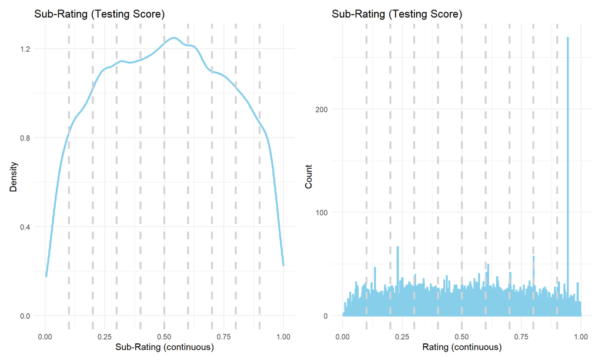

RD results for number of Black students in 2019 (running variable sub-rating test scores)

|  | N Black students 2019 (No Covs) | N Black students 2019 (Covs) |
| --- | --- | --- |
| 1-2 | -26.937* | 2.108 |
|  | (13.81) | (13.915) |
|  | [868;947] | [409;431] |
| 2-3 | 11.168 | 13.723 |
|  | (10.875) | (9.739) |
|  | [1400;1572] | [961;1033] |
| 3-4 | 19.862* | 13.76 |
|  | (10.404) | (9.628) |
|  | [1187;1454] | [895;1082] |
| 4-5 | 13.626 | 10.039 |
|  | (9.582) | (9.041) |
|  | [1279;1266] | [870;792] |
| 5-6 | -39.447*** | -31.889*** |
|  | (12.305) | (11.318) |
|  | [683;786] | [441;512] |
| 6-7 | 52.195*** | 52.797*** |
|  | (10.475) | (8.88) |
|  | [1048;1186] | [975;1126] |
| 7-8 | 29.041*** | 24.168*** |
|  | (8.281) | (6.72) |
|  | [752;753] | [912;934] |
| 8-9 | -7.7 | 2.22 |
|  | (7.23) | (5.409) |
|  | [1234;1145] | [978;967] |
| 9-10 | 10.312 | 9.94 |
|  | (7.051) | (6.098) |
|  | [565;531] | [484;423] |

Standard error in parenthesis and effective sample size in brackets

# Other Approach: Matching

Another strategy that we could follow is to take advantage of the rounding that happens at the subrating level, and match schools that have similar running variable $r*$, but because of the subrating rounding, end up with different rating $R$.

For this, we use Mixed-Integer Programming (MIP) Matching and a cardinality matching approach to get the largest matched sample possible under strict balance restrictions. In this case, we set the following balancing constraints:

- Restricted mean balance: 0.01 SD in running variable $r*$; 0.05 SD in number of black individuals 2010, 2013 enrollment, and test score subrating (continuous).
- Fine balance: Distributional balance for states.

In total, we are able to match 3522 observations.

Balance Table - Matching on r*

|  | Mis | Min | Max | Mean T | Mean C | Std Dif | P-val |
| --- | --- | --- | --- | --- | --- | --- | --- |
| N Black 2010 | 0 | 0.00 | 16804.00 | 579.12 | 566.30 | 0.01 | 0.68 |
| N Black 2013 | 0 | 0.00 | 883.00 | 101.53 | 109.33 | -0.05 | 0.11 |
| Enrollment 2013 | 0 | 56.00 | 2005.00 | 545.80 | 539.68 | 0.03 | 0.42 |
| Subrating Test | 0 | 0.02 | 0.99 | 0.50 | 0.50 | 0.00 | 0.91 |
| Rating Cont (r*) | 0 | 1.50 | 9.79 | 5.13 | 5.13 | 0.00 | 0.98 |
| N Black 2015 | 0 | 0.00 | 811.00 | 101.89 | 106.41 | -0.03 | 0.33 |
| N Black 2014 | 0 | 0.00 | 843.00 | 102.20 | 108.14 | -0.04 | 0.21 |

Matching results for schools marked down for rounding (T) and schools marked the same (C)

|  | Diff. N Black students 2019 (T-C) |
| --- | --- |
| 2 | -16.05 |
|  | (17.5) |
| 3 | 5.79 |
|  | (12.6) |
| 4 | 31.53*** |
|  | (10.87) |
| 5 | 7.84 |
|  | (8.11) |
| 6 | -18.38** |
|  | (7.44) |
| 7 | -3.79 |
|  | (6.43) |
| 8 | -19.68*** |
|  | (5.82) |
| 9 | 18.85* |
|  | (10.8) |
| 10 | -8 |
|  | (18.211) |

These results seem to be driven by the imbalance in 2013 demographic characteristics. Once we adjust by those, most differences disappear:

In total, we are able to match 3504 observations.

Balance Table - Matching on r*

|  | Mis | Min | Max | Mean T | Mean C | Std Dif | P-val |
| --- | --- | --- | --- | --- | --- | --- | --- |
| N Black 2010 | 0 | 0.00 | 8623.00 | 577.82 | 563.78 | 0.02 | 0.64 |
| N Black 2013 | 0 | 0.00 | 752.00 | 102.55 | 103.72 | -0.01 | 0.80 |
| Enrollment 2013 | 0 | 56.00 | 2005.00 | 546.32 | 541.26 | 0.02 | 0.51 |
| Subrating Test | 0 | 0.02 | 0.99 | 0.50 | 0.50 | 0.00 | 0.93 |
| Rating Cont (r*) | 0 | 1.50 | 9.74 | 5.12 | 5.13 | 0.00 | 0.98 |
| N Black 2015 | 0 | 0.00 | 824.00 | 103.39 | 101.09 | 0.02 | 0.62 |
| N Black 2014 | 0 | 0.00 | 778.00 | 103.41 | 102.38 | 0.01 | 0.83 |

Matching results for schools marked down for rounding (T) and schools marked the same (C) - Matching using 2013 demographics

|  | Diff. N Black students 2019 (T-C) |
| --- | --- |
| 2 | 14.77 |
|  | (18.1) |
| 3 | 27.03** |
|  | (11.94) |
| 4 | 8.58 |
|  | (11.18) |
| 5 | 4.1 |
|  | (7.8) |
| 6 | -2.73 |
|  | (5.89) |
| 7 | 2.89 |
|  | (6.02) |
| 8 | -2.22 |
|  | (4.26) |
| 9 | 6.36 |
|  | (11.22) |
| 10 | 7.78 |
|  | (13.452) |